# ml project

Gustavo Rosell Romo

17 de junio de 2018

# Introduction to the project

## Background

Using devices such as Jawbone Up, Nike FuelBand, and Fitbit it is now possible to collect a large amount of data about personal activity relatively inexpensively. These type of devices are part of the quantified self movement – a group of enthusiasts who take measurements about themselves regularly to improve their health, to find patterns in their behavior, or because they are tech geeks. One thing that people regularly do is quantify how much of a particular activity they do, but they rarely quantify how well they do it.

In this project, your goal will be to use data from accelerometers on the belt, forearm, arm, and dumbell of 6 participants. They were asked to perform barbell lifts correctly and incorrectly in 5 different ways. More information is available from the website here: http://groupware.les.inf.puc-rio.br/har (see the section on the Weight Lifting Exercise Dataset).

## Data

The training data for this project are available here: https://d396qusza40orc.cloudfront.net/predmachlearn/pml-training.csv

The test data are available here: https://d396qusza40orc.cloudfront.net/predmachlearn/pml-testing.csv

The data for this project come from this source: http://groupware.les.inf.puc-rio.br/har. If you use the document you create for this class for any purpose please cite them as they have been very generous in allowing their data to be used for this kind of assignment.

## What you should submit

The goal of your project is to predict the manner in which they did the exercise. This is the “classe” variable in the training set. You may use any of the other variables to predict with. You should create a report describing how you built your model, how you used cross validation, what you think the expected out of sample error is, and why you made the choices you did. You will also use your prediction model to predict 20 different test cases.

Your submission should consist of a link to a Github repo with your R markdown and compiled HTML file describing your analysis. Please constrain the text of the writeup to < 2000 words and the number of figures to be less than 5. It will make it easier for the graders if you submit a repo with a gh-pages branch so the HTML page can be viewed online (and you always want to make it easy on graders :-).

You should also apply your machine learning algorithm to the 20 test cases available in the test data above. Please submit your predictions in appropriate format to the programming assignment for automated grading. See the programming assignment for additional details.

# Analysis

## Summary of approach

1<-Load the data set and briefly learn the characteristics of the data

2<-Use cross-validation method to built a valid model; 70% of the original data is used for model building (training data) while the rest of 30% of the data is used for testing (testing data)

3<-Since the number of variables in the training data is too large, clean the data by 1) excluding variables which apparently cannot be explanatory variables, and 2) reducing variables with little information.

4<-Apply PCA to reduce the number of variables

5<-Apply random forest method to build a model

6<-Check the model with the testing data set

7<-Apply the model to estimate classes of 20 observations

## Loading data

```r
data <- read.csv("pml-training.csv")
colnames(data)
```

```
##   [1] "X"                        "user_name"
##   [3] "raw_timestamp_part_1"     "raw_timestamp_part_2"
##   [5] "cvtd_timestamp"           "new_window"
##   [7] "num_window"               "roll_belt"
##   [9] "pitch_belt"               "yaw_belt"
##  [11] "total_accel_belt"         "kurtosis_roll_belt"
##  [13] "kurtosis_picth_belt"      "kurtosis_yaw_belt"
##  [15] "skewness_roll_belt"       "skewness_roll_belt.1"
##  [17] "skewness_yaw_belt"        "max_roll_belt"
##  [19] "max_picth_belt"           "max_yaw_belt"
##  [21] "min_roll_belt"            "min_pitch_belt"
##  [23] "min_yaw_belt"             "amplitude_roll_belt"
##  [25] "amplitude_pitch_belt"     "amplitude_yaw_belt"
##  [27] "var_total_accel_belt"     "avg_roll_belt"
##  [29] "stddev_roll_belt"         "var_roll_belt"
```

[output cut: 65 more lines]

```r
summary(data)
```

[output not shown]

[output cut: 313 more lines]

```
##  Min.   :-446.00   Min.   :-1280.0   Min.   :-896.0   Min.   :-973.0
##  1st Qu.:-182.00   1st Qu.: -616.0   1st Qu.:   2.0   1st Qu.: 191.0
##  Median : -39.00   Median : -378.0   Median : 591.0   Median : 511.0
##  Mean   : -55.29   Mean   : -312.6   Mean   : 380.1   Mean   : 393.6
##  3rd Qu.:  26.00   3rd Qu.:  -73.0   3rd Qu.: 737.0   3rd Qu.: 653.0
##  Max.   : 291.00   Max.   :  672.0   Max.   :1480.0   Max.   :1090.0
##
##  classe
##  A:5580
##  B:3797
##  C:3422
##  D:3216
##  E:3607
##
##
```

## Cross validation

use 70% of training set data to built a model, and use the rest to test the model

```r
library(caret)
set.seed(12345)
train <- createDataPartition(y=data$classe,p=.70,list=F)
training <- data[train,]
testing <- data[-train,]
```

## Cleaning the training data

```r
#exclude identifier, timestamp, and window data (they cannot be used for prediction)
Cl <- grep("name|timestamp|window|X", colnames(training), value=F)
trainingCl <- training[,-Cl]
#select variables with high (over 95%) missing data --> exclude them from the analysis
trainingCl[trainingCl==""] <- NA
NArate <- apply(trainingCl, 2, function(x) sum(is.na(x)))/nrow(trainingCl)
trainingCl <- trainingCl[!(NArate>0.95)]
summary(trainingCl)
```

```
##    roll_belt        pitch_belt         yaw_belt       total_accel_belt
##  Min.   :-28.90   Min.   :-54.700   Min.   :-180.00   Min.   : 0.00
##  1st Qu.:  1.10   1st Qu.:  1.690   1st Qu.: -88.30   1st Qu.: 3.00
##  Median :113.00   Median :  5.280   Median : -13.00   Median :17.00
##  Mean   : 64.44   Mean   :  0.231   Mean   : -10.91   Mean   :11.32
##  3rd Qu.:123.00   3rd Qu.: 14.800   3rd Qu.:  13.60   3rd Qu.:18.00
##  Max.   :162.00   Max.   : 60.200   Max.   : 179.00   Max.   :28.00
##   gyros_belt_x        gyros_belt_y       gyros_belt_z
##  Min.   :-1.040000   Min.   :-0.51000   Min.   :-1.3500
##  1st Qu.:-0.050000   1st Qu.: 0.00000   1st Qu.:-0.2000
##  Median : 0.030000   Median : 0.02000   Median :-0.1000
##  Mean   :-0.007106   Mean   : 0.03958   Mean   :-0.1311
##  3rd Qu.: 0.110000   3rd Qu.: 0.11000   3rd Qu.:-0.0200
##  Max.   : 2.220000   Max.   : 0.64000   Max.   : 1.6100
##   accel_belt_x       accel_belt_y     accel_belt_z     magnet_belt_x
##  Min.   :-120.000   Min.   :-69.00   Min.   :-269.00   Min.   :-48.00
##  1st Qu.: -21.000   1st Qu.:  3.00   1st Qu.:-162.00   1st Qu.:  9.00
##  Median : -15.000   Median : 35.00   Median :-152.00   Median : 34.00
##  Mean   :  -5.506   Mean   : 30.15   Mean   : -72.67   Mean   : 55.64
##  3rd Qu.:  -5.000   3rd Qu.: 61.00   3rd Qu.:  27.00   3rd Qu.: 60.00
##  Max.   :  85.000   Max.   :164.00   Max.   : 105.00   Max.   :479.00
##  magnet_belt_y   magnet_belt_z       roll_arm         pitch_arm
##  Min.   :359.0   Min.   :-623.0   Min.   :-180.00   Min.   :-88.800
##  1st Qu.:582.0   1st Qu.:-375.0   1st Qu.: -31.00   1st Qu.:-26.000
##  Median :601.0   Median :-319.0   Median :   0.00   Median :  0.000
##  Mean   :593.8   Mean   :-345.3   Mean   :  18.04   Mean   : -4.599
##  3rd Qu.:610.0   3rd Qu.:-306.0   3rd Qu.:  77.20   3rd Qu.: 11.300
##  Max.   :673.0   Max.   : 293.0   Max.   : 180.00   Max.   : 88.500
##     yaw_arm         total_accel_arm  gyros_arm_x        gyros_arm_y
##  Min.   :-180.000   Min.   : 1.00   Min.   :-6.37000   Min.   :-3.4000
##  1st Qu.: -42.900   1st Qu.:17.00   1st Qu.:-1.32000   1st Qu.:-0.8000
##  Median :   0.000   Median :27.00   Median : 0.08000   Median :-0.2600
##  Mean   :  -1.125   Mean   :25.56   Mean   : 0.04806   Mean   :-0.2587
##  3rd Qu.:  45.300   3rd Qu.:33.00   3rd Qu.: 1.59000   3rd Qu.: 0.1400
##  Max.   : 180.000   Max.   :66.00   Max.   : 4.87000   Max.   : 2.8400
##   gyros_arm_z       accel_arm_x       accel_arm_y       accel_arm_z
##  Min.   :-2.3300   Min.   :-383.00   Min.   :-318.00   Min.   :-636.00
##  1st Qu.:-0.0700   1st Qu.:-241.00   1st Qu.: -54.00   1st Qu.:-144.00
##  Median : 0.2300   Median : -41.00   Median :  14.00   Median : -46.00
##  Mean   : 0.2714   Mean   : -58.62   Mean   :  32.33   Mean   : -71.51
```

[output cut: 50 more lines]

```
##  Max.   :311.00000   Max.   :231.0000   Max.   : 389.00   Max.   : 923.0
##  accel_forearm_z   magnet_forearm_x  magnet_forearm_y magnet_forearm_z
##  Min.   :-410.00   Min.   :-1280.0   Min.   :-896.0   Min.   :-966.0
##  1st Qu.:-183.00   1st Qu.: -617.0   1st Qu.:  -3.0   1st Qu.: 194.0
##  Median : -42.00   Median : -383.0   Median : 587.0   Median : 511.0
##  Mean   : -56.63   Mean   : -314.7   Mean   : 375.8   Mean   : 395.6
##  3rd Qu.:  25.00   3rd Qu.:  -77.0   3rd Qu.: 736.0   3rd Qu.: 652.0
##  Max.   : 287.00   Max.   :  672.0   Max.   :1480.0   Max.   :1090.0
##  classe
##  A:3906
##  B:2658
##  C:2396
##  D:2252
##  E:2525
##
```

## PCA

Since the number of variables are still over 50, PCA is applied

```r
preProc <- preProcess(trainingCl[,1:52],method="pca",thresh=.8) #12 components are required
preProc <- preProcess(trainingCl[,1:52],method="pca",thresh=.9) #18 components are required
preProc <- preProcess(trainingCl[,1:52],method="pca",thresh=.95) #25 components are required

preProc <- preProcess(trainingCl[,1:52],method="pca",pcaComp=25)
preProc$rotation
```

```
##                                PC1          PC2           PC3
## roll_belt            -0.2816191101  0.181115869 -0.0683188988
## pitch_belt           -0.0721225635 -0.283411928 -0.0718624404
## yaw_belt             -0.1557725870  0.283474029 -0.0162832303
## total_accel_belt     -0.2815622818  0.161173813 -0.0889225375
## gyros_belt_x          0.1290011265  0.172519149  0.1864328034
## gyros_belt_y         -0.0638305758  0.222671177  0.0787091643
## gyros_belt_z          0.1864028904  0.015456330  0.0967732005
## accel_belt_x          0.0578371033  0.288833601  0.0887246517
## accel_belt_y         -0.3062519827  0.092151715 -0.0970120456
## accel_belt_z          0.2943733755 -0.158957445  0.0638357436
## magnet_belt_x         0.0321441356  0.288414874  0.0473559630
## magnet_belt_y         0.1291079762  0.064027122 -0.0793945866
## magnet_belt_z         0.0791992389  0.105496583 -0.0653231649
## roll_arm              0.0299254984 -0.185324262  0.0610910039
## pitch_arm             0.0458000648  0.061433369 -0.2217161976
## yaw_arm               0.0308389896 -0.124772286  0.0095279080
## total_accel_arm       0.1000684882 -0.055490267  0.0577412200
## gyros_arm_x           0.0004303138  0.054798569  0.0004365336
## gyros_arm_y           0.0576897016 -0.094532889 -0.0053615470
## gyros_arm_z          -0.1209236142  0.209761859  0.0673845010
## accel_arm_x          -0.1771573062 -0.079772870  0.1671863189
## accel_arm_y           0.2416836758 -0.170488103 -0.1318701660
## accel_arm_z          -0.1276908251  0.016655254 -0.2669012957
## magnet_arm_x         -0.0901733458  0.002440190  0.2570395224
## magnet_arm_y          0.0656089075  0.015244057 -0.3591577822
## magnet_arm_z          0.0351490498  0.021097397 -0.2998838028
## roll_dumbbell         0.1092631829  0.110689220  0.0559095093
## pitch_dumbbell       -0.1311291844 -0.129631040  0.0912440657
## yaw_dumbbell         -0.1686570251 -0.240804530  0.0052086714
## total_accel_dumbbell  0.1897518338  0.115434665 -0.1118973145
## gyros_dumbbell_x     -0.0074574452 -0.006866442 -0.1747316551
## gyros_dumbbell_y      0.0081491137  0.037253894  0.1352234322
## gyros_dumbbell_z      0.0037343113  0.003203790  0.1591744228
## accel_dumbbell_x     -0.1888836611 -0.107883370  0.1278212505
## accel_dumbbell_y      0.2092670687  0.145652920 -0.0007173579
## accel_dumbbell_z     -0.1936380517 -0.216541773  0.0712495651
## magnet_dumbbell_x    -0.2009376317 -0.162430764 -0.1316229360
## magnet_dumbbell_y     0.1773047176  0.142615157  0.1944876619
## magnet_dumbbell_z     0.1639109840 -0.049381040  0.1822749634
```

[output cut: 316 more lines]

```
## magnet_dumbbell_y    -0.174411250  0.040824208
## magnet_dumbbell_z     0.068951121 -0.035810815
## roll_forearm          0.098224244 -0.085955836
## pitch_forearm         0.003306890  0.099006497
## yaw_forearm          -0.030929423 -0.026946564
## total_accel_forearm  -0.052392312  0.051629200
## gyros_forearm_x      -0.103640297  0.189242885
## gyros_forearm_y       0.016828604  0.061504036
## gyros_forearm_z      -0.094996497  0.106171896
## accel_forearm_x       0.043707079  0.112235117
## accel_forearm_y       0.050497278 -0.025348494
## accel_forearm_z      -0.233386244 -0.134339177
## magnet_forearm_x     -0.064742051  0.078484906
## magnet_forearm_y     -0.055973873  0.096992908
## magnet_forearm_z     -0.124093556 -0.031787029
```

```r
trainingPC <- predict(preProc,trainingCl[,1:52])
```

## Random forest

Apply ramdom forest method (non-bionominal outcome & large sample size)

```r
library(randomForest)
modFitRF <- randomForest(trainingCl$classe ~ .,   data=trainingPC, do.trace=F)
print(modFitRF)
```

```
##
## Call:
##  randomForest(formula = trainingCl$classe ~ ., data = trainingPC,      do.trace = F)
##                Type of random forest: classification
##                      Number of trees: 500
## No. of variables tried at each split: 5
##
##         OOB estimate of  error rate: 2.54%
## Confusion matrix:
##      A    B    C    D    E class.error
## A 3870   12   14    6    4  0.00921659
## B   49 2564   37    1    7  0.03536494
## C    6   35 2321   29    5  0.03130217
## D    4    1   92 2149    6  0.04573712
## E    2   12   15   12 2484  0.01623762
```

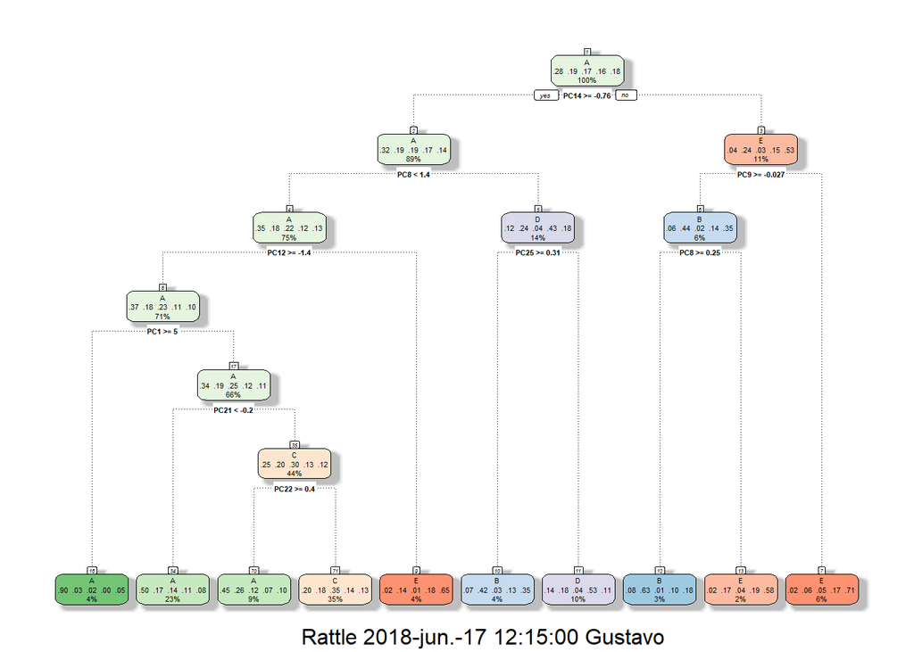

```r
# view results
library(rpart.plot)
library(rpart)
library(RColorBrewer)
library(rattle)
modFitRF1 <- rpart(trainingCl$classe ~ ., data=trainingPC, method="class")
fancyRpartPlot(modFitRF1)
```

## Check with test set

```r
testingCl <- testing[,-Cl]
testingCl[testingCl==""] <- NA
NArate <- apply(testingCl, 2, function(x) sum(is.na(x)))/nrow(testingCl)
testingCl <- testingCl[!(NArate>0.95)]
testingPC <- predict(preProc,testingCl[,1:52])
confusionMatrix(testingCl$classe,predict(modFitRF,testingPC))
```

```
## Confusion Matrix and Statistics
##
##           Reference
## Prediction    A    B    C    D    E
##          A 1662    5    5    2    0
##          B   19 1101   16    0    3
##          C    4   20  989   12    1
##          D    0    2   48  911    3
##          E    0    2    6    7 1067
##
## Overall Statistics
##
##                Accuracy : 0.9737
##                  95% CI : (0.9692, 0.9776)
##     No Information Rate : 0.2863
##     P-Value [Acc > NIR] : < 2.2e-16
##
##                   Kappa : 0.9667
##  Mcnemar's Test P-Value : NA
##
## Statistics by Class:
##
##                      Class: A Class: B Class: C Class: D Class: E
## Sensitivity            0.9864   0.9743   0.9295   0.9775   0.9935
## Specificity            0.9971   0.9920   0.9923   0.9893   0.9969
## Pos Pred Value         0.9928   0.9666   0.9639   0.9450   0.9861
## Neg Pred Value         0.9945   0.9939   0.9846   0.9957   0.9985
## Prevalence             0.2863   0.1920   0.1808   0.1584   0.1825
## Detection Rate         0.2824   0.1871   0.1681   0.1548   0.1813
## Detection Prevalence   0.2845   0.1935   0.1743   0.1638   0.1839
## Balanced Accuracy      0.9917   0.9832   0.9609   0.9834   0.9952
```

## Predict classes of 20 test data

```r
testdata <- read.csv("pml-testing.csv")
testdataCl <- testdata[,-Cl]
testdataCl[testdataCl==""] <- NA
NArate <- apply(testdataCl, 2, function(x) sum(is.na(x)))/nrow(testdataCl)
testdataCl <- testdataCl[!(NArate>0.95)]
testdataPC <- predict(preProc,testdataCl[,1:52])
testdataCl$classe <- predict(modFitRF,testdataPC)
print(testdataCl$classe)
```

```
##  [1] B A A A A E D B A A B C B A E E A B B B
## Levels: A B C D E
```

## Discussion

In this analyses, 19622 observations from weight lifting exercise were used to analyze and predict correct body movement from others during the exercise. 70% of the total observations (13737 observations) were used to build a model by random forest method, and the rest of 30% of the observations (5885 observations) were used for model validation (cross-validation).

### Reference

Ugulino, W.; Cardador, D.; Vega, K.; Velloso, E.; Milidiu, R.; Fuks, H. Wearable Computing: Accelerometers’ Data Classification of Body Postures and Movements. Proceedings of 21st Brazilian Symposium on Artificial Intelligence. Advances in Artificial Intelligence - SBIA 2012. In: Lecture Notes in Computer Science. , pp. 52-61. Curitiba, PR: Springer Berlin / Heidelberg, 2012. ISBN 978-3-642-34458-9. DOI: 10.1007/978-3-642-34459-6_6. Cited by 2 (Google Scholar)